# Homework: Numerical linear algebra

# Exercise 1: Comparing different numerical linear algebra algorithms for solving linear systems

In this exercise, we consider the problem of solving a linear system $\bA \bx = \bb$ for $\bx$. We compare the three methods we learned in the class: LU, Cholesky, and QR decompositions. (Of course, LU applies to more general systems and QR can be used to solve least squares, but here we focus on positive definite systems.)

## Part A: Racing for solution — speed comparison

We first compare their computational speed. Fill in the code below and `bench::mark()` the three algorithms.

**Questions:** What are relative speeds among the algorithms? Do relative speeds agree with what you expect from the complexity analyses? If not (quite), why might that be?  
**Answers:** LU costs around 133ms, cholesky decomposition costs around 180ms, QR decomposition costs around 500ms. The relative speeds between cholesky and QR agrees with what I expect from the complexity analysis because QR has a cost of $O(2np^2)$ while cholesky has $O(\frac{1}{3}p^3)$. Hence, when n (sample size) is large, we expect QR to be slower than cholesky. However, the relative speed for LU is not what I expect from the complexity analyses because LU is expected to have a cost of $O(\frac{2}{3}p^3)$. This could be due to the fact that LU decomposition in solve() function uses the LAPACK package which uses a more efficient version of triangular backsolve or forwardsolve than the function I wrote.

**Note:** I misspoke about the R’s built-in `chol()` function during the lecture: when applied to a positive-definite `A`, the function actually returns an *upper-triangular* matrix `R` such that `t(R) %*% R == A`.

```r
# Import the `rand_positive_def_matrix` function
source(file.path("R", "random_matrix.R"))

mat_size <- 1024L
A <- rand_positive_def_matrix(mat_size, cond_num = 1e3)
b <- rnorm(mat_size)

solve_via_cholesky <- function(A, b) {
  L <- t(chol(A))
  x <- backsolve(t(L), forwardsolve(L, b))
  return(x)
}

bench::mark(
  solve(A, b)
)
```

```
## # A tibble: 1 × 6
##   expression       min   median `itr/sec` mem_alloc `gc/sec`
##   <bch:expr>  <bch:tm> <bch:tm>     <dbl> <bch:byt>    <dbl>
## 1 solve(A, b)    135ms    135ms      7.41    8.06MB        0
```

```r
bench::mark(
  solve_via_cholesky(A, b)
)
```

```
## # A tibble: 1 × 6
##   expression                    min   median `itr/sec` mem_alloc `gc/sec`
##   <bch:expr>               <bch:tm> <bch:tm>     <dbl> <bch:byt>    <dbl>
## 1 solve_via_cholesky(A, b)    177ms    178ms      5.61    24.1MB     2.81
```

```r
bench::mark(
  qr.solve(A, b)
)
```

```
## # A tibble: 1 × 6
##   expression          min   median `itr/sec` mem_alloc `gc/sec`
##   <bch:expr>     <bch:tm> <bch:tm>     <dbl> <bch:byt>    <dbl>
## 1 qr.solve(A, b)    495ms    495ms      2.02    32.2MB     2.02
```

## Part B: Competition in terms of numerical accuracy/stability

We now compare the three methods in terms of numerical accuracy/stability. To this end, we set up the following simulation study. We first generate a “ground truth” solution vector $\bx_0$. We then compute an “numerical-error-free” $\bb = \bA \bx_0$ by carrying out the matrix-vector multiplication using the `long double` type, which (on most hardware and compilers) provides [additional 12 bits of precision](https://en.wikipedia.org/wiki/Extended_precision#x86_extended_precision_format). Of course, the vector $\bb$ computed as such still suffers from numerical errors, but the idea is that the numerical errors from this high-precision matrix-vector multiplication is much smaller than the errors caused by numerically solving $\bA \bx = \bb$ for $\bx$. We can thus assess the accuracy of the three solvers by comparing the numerically computed $\bx$ to the ground truth $\bx_0$.

### Task ⼀

First compare the outputs of matrix-vector multiplication $\bx \to \bA \bx$ using `double` and `long double` using the provided Rcpp functions.

**Questions:** What is the relative difference in $\ell^2$-norm? How about the coordinate-wise relative differences? Are the observed magnitudes of the differences what you’d expect?

```r
Rcpp::sourceCpp(file.path("src", "matvec_double.cpp"))
Rcpp::sourceCpp(file.path("src", "matvec_ldouble.cpp"))

set.seed(1918)

mat_size <- 1024L
A <- rand_positive_def_matrix(mat_size, cond_num = 1e3)
x <- rnorm(mat_size)

matvec_double_result <- matvec_double(A, x)
matvec_ldouble_result <- matvec_ldouble(A, x)
rel_diff <- (sqrt(sum((matvec_double_result-matvec_ldouble_result)^2)))/sqrt(sum(matvec_ldouble_result^2))
rel_diff
```

```
## [1] 1.185409e-15
```

```r
coord_diff <- (matvec_double_result-matvec_ldouble_result)/matvec_ldouble_result
head(coord_diff,10)
```

```
##  [1]  6.711719e-15  7.143505e-15  3.238438e-15 -1.080999e-15 -7.562921e-16
##  [6] -2.451349e-15  2.382406e-15  5.675859e-16  5.341415e-16  5.564046e-15
```

### Task ⼆

Now randomly generate $\bA$ so that its condition number is $10^6$. Then solve a positive-definite system $\bA \bx = \bb$ for $\bx$ using the three algorithms and compare their outputs to the ground truth $\bx_0$.

**Questions:** Which algorithm appears to be more accurate than the others? Visually demonstrate your answer.

**Answer:** From the graph, we can see that solve() is more accurate than the others.

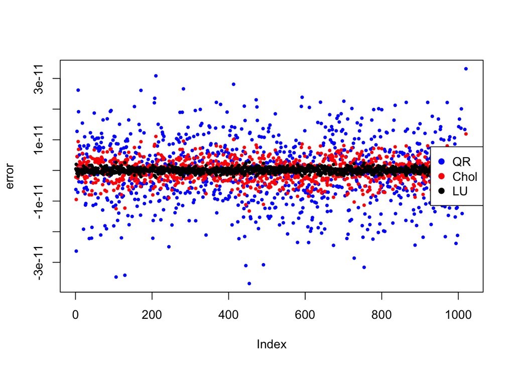

```r
set.seed(1918)
cond_num <- 1e6

# Larger matrices could incur substantial computational time under base R BLAS
mat_size <- 1024L

A <- rand_positive_def_matrix(mat_size, cond_num)
x <- rnorm(mat_size)

b <- matvec_ldouble(A, x)
method1 <- solve(A, b)
method_chol <- solve_via_cholesky(A, b)
method_qr <- qr.solve(A, b)

plot(method_qr-x, col="blue", ylab="error", pch=19, cex=0.5)
points(method_chol-x, col="red", pch=19, cex=0.5)
points(method1-x, col="black", pch=19, cex=0.5)
legend("right", legend = c("QR", "Chol", "LU"), col = c("blue", "red", "black"), pch = c(19,19,19))
```

### Task 三

In Task ⼆, we compared the three algorithms in one randomly generated example. Now we consider a more systematic (though hardly comprehensive) comparison via repeated simulations. We also vary the condition number of $\bA$ and assess whether the results would hold across varying degrees of ill-conditioning.

**Questions/To-do’s:**

- Using the starter code provided, calculate various summary measures of the numerical errors.
- Integrate into the provided code one another (or more, if you like) meaningful metric(s) of your choice to summarize the numerical error.
- Visually explore how the three algorithms compare with each other in their accuracy. See if different error metrics tell different stories; they might or might not.
- Vary the condition number in the range $10^6 \sim 10^{12}$, e.g. by trying $10^6$, $10^9$, and $10^{12}$.
- Do you see any patterns in the numerical errors across the three algorithms, metrics, and/or condition numbers? Show some plots to support your conclusion.

**Note:** The QR solver will throw an error when the system is ill-condition enough that the numerical solution might not be very accurate. To force it to return the solution in any case, set `tol = .Machine$double.eps`.

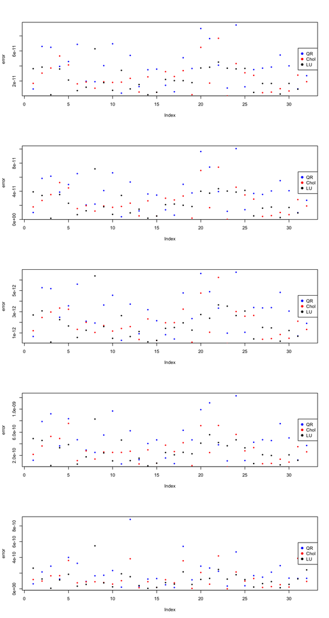

```r
# Utility functions for bookkeeping simulation results.
source(file.path("R", "num_linalg_sim_study_helper.R"))

n_sim <- 32L
mat_size <- 512L
cond_num <- 1e6
metrics <- c("norm", "median", "five_percentile", "ninety_five_percentile", "average")
  # TODO: add another metric and modify the helper script accordingly

rel_error_list <- lapply(
  c("lu", "chol", "qr"),
  function(method) pre_allocate_error_list(n_sim, metrics)
)

for (sim_index in 1:n_sim) {
  A <- rand_positive_def_matrix(mat_size, cond_num)
  x <- rnorm(mat_size)
  b <- matvec_ldouble(A, x)
  x_approx <- list(
    lu=solve(A, b),
    chol=solve_via_cholesky(A, b),
    qr=qr.solve(A, b, tol = .Machine$double.eps)
  )
  for (method in c("lu", "chol", "qr")) {
    rel_error <- lapply(
      metrics,
      function (metric) calc_rel_error(x, x_approx[[method]], metric)
    )
    names(rel_error) <- metrics
    for (metric in names(rel_error)) {
      rel_error_list[[method]][[metric]][sim_index] <- rel_error[[metric]]
    }
  }
}

# TODO: visually compare errors
par(mfrow=c(5,1))
plot(rel_error_list[["qr"]][["norm"]], col="blue", ylab="error", pch=19, cex=0.5)
points(rel_error_list[["chol"]][["norm"]], col="red", pch=19, cex=0.5)
points(rel_error_list[["lu"]][["norm"]], col="black", pch=19, cex=0.5)
legend("right", legend = c("QR", "Chol", "LU"), col = c("blue", "red", "black"), pch = c(19,19,19))

plot(rel_error_list[["qr"]][["median"]], col="blue", ylab="error", pch=19, cex=0.5)
points(rel_error_list[["chol"]][["median"]], col="red", pch=19, cex=0.5)
points(rel_error_list[["lu"]][["median"]], col="black", pch=19, cex=0.5)
legend("right", legend = c("QR", "Chol", "LU"), col = c("blue", "red", "black"), pch = c(19,19,19))

plot(rel_error_list[["qr"]][["five_percentile"]], col="blue", ylab="error", pch=19, cex=0.5)
points(rel_error_list[["chol"]][["five_percentile"]], col="red", pch=19, cex=0.5)
points(rel_error_list[["lu"]][["five_percentile"]], col="black", pch=19, cex=0.5)
legend("right", legend = c("QR", "Chol", "LU"), col = c("blue", "red", "black"), pch = c(19,19,19))

plot(rel_error_list[["qr"]][["ninety_five_percentile"]], col="blue", ylab="error", pch=19, cex=0.5)
points(rel_error_list[["chol"]][["ninety_five_percentile"]], col="red", pch=19, cex=0.5)
points(rel_error_list[["lu"]][["ninety_five_percentile"]], col="black", pch=19, cex=0.5)
legend("right", legend = c("QR", "Chol", "LU"), col = c("blue", "red", "black"), pch = c(19,19,19))

plot(rel_error_list[["qr"]][["average"]], col="blue", ylab="error", pch=19, cex=0.5)
points(rel_error_list[["chol"]][["average"]], col="red", pch=19, cex=0.5)
points(rel_error_list[["lu"]][["average"]], col="black", pch=19, cex=0.5)
legend("right", legend = c("QR", "Chol", "LU"), col = c("blue", "red", "black"), pch = c(19,19,19))
```

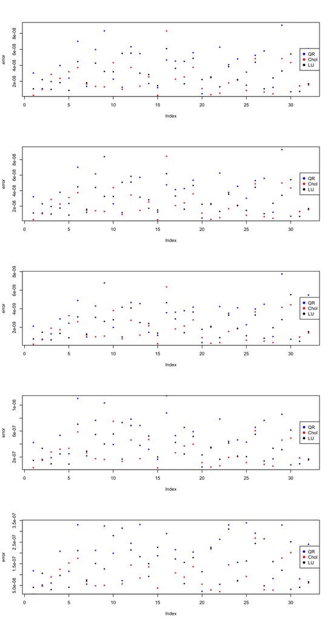

```r
# Utility functions for bookkeeping simulation results.
source(file.path("R", "num_linalg_sim_study_helper.R"))

n_sim <- 32L
mat_size <- 512L
cond_num <- 1e9
metrics <- c("norm", "median", "five_percentile", "ninety_five_percentile", "average")
  # TODO: add another metric and modify the helper script accordingly

rel_error_list <- lapply(
  c("lu", "chol", "qr"),
  function(method) pre_allocate_error_list(n_sim, metrics)
)

for (sim_index in 1:n_sim) {
  A <- rand_positive_def_matrix(mat_size, cond_num)
  x <- rnorm(mat_size)
  b <- matvec_ldouble(A, x)
  x_approx <- list(
    lu=solve(A, b),
    chol=solve_via_cholesky(A, b),
    qr=qr.solve(A, b, tol = .Machine$double.eps)
  )
  for (method in c("lu", "chol", "qr")) {
    rel_error <- lapply(
      metrics,
      function (metric) calc_rel_error(x, x_approx[[method]], metric)
    )
    names(rel_error) <- metrics
    for (metric in names(rel_error)) {
      rel_error_list[[method]][[metric]][sim_index] <- rel_error[[metric]]
    }
  }
}

# TODO: visually compare errors
par(mfrow=c(5,1))
plot(rel_error_list[["qr"]][["norm"]], col="blue", ylab="error", pch=19, cex=0.5)
points(rel_error_list[["chol"]][["norm"]], col="red", pch=19, cex=0.5)
points(rel_error_list[["lu"]][["norm"]], col="black", pch=19, cex=0.5)
legend("right", legend = c("QR", "Chol", "LU"), col = c("blue", "red", "black"), pch = c(19,19,19))

plot(rel_error_list[["qr"]][["median"]], col="blue", ylab="error", pch=19, cex=0.5)
points(rel_error_list[["chol"]][["median"]], col="red", pch=19, cex=0.5)
points(rel_error_list[["lu"]][["median"]], col="black", pch=19, cex=0.5)
legend("right", legend = c("QR", "Chol", "LU"), col = c("blue", "red", "black"), pch = c(19,19,19))

plot(rel_error_list[["qr"]][["five_percentile"]], col="blue", ylab="error", pch=19, cex=0.5)
points(rel_error_list[["chol"]][["five_percentile"]], col="red", pch=19, cex=0.5)
points(rel_error_list[["lu"]][["five_percentile"]], col="black", pch=19, cex=0.5)
legend("right", legend = c("QR", "Chol", "LU"), col = c("blue", "red", "black"), pch = c(19,19,19))

plot(rel_error_list[["qr"]][["ninety_five_percentile"]], col="blue", ylab="error", pch=19, cex=0.5)
points(rel_error_list[["chol"]][["ninety_five_percentile"]], col="red", pch=19, cex=0.5)
points(rel_error_list[["lu"]][["ninety_five_percentile"]], col="black", pch=19, cex=0.5)
legend("right", legend = c("QR", "Chol", "LU"), col = c("blue", "red", "black"), pch = c(19,19,19))

plot(rel_error_list[["qr"]][["average"]], col="blue", ylab="error", pch=19, cex=0.5)
points(rel_error_list[["chol"]][["average"]], col="red", pch=19, cex=0.5)
points(rel_error_list[["lu"]][["average"]], col="black", pch=19, cex=0.5)
legend("right", legend = c("QR", "Chol", "LU"), col = c("blue", "red", "black"), pch = c(19,19,19))
```

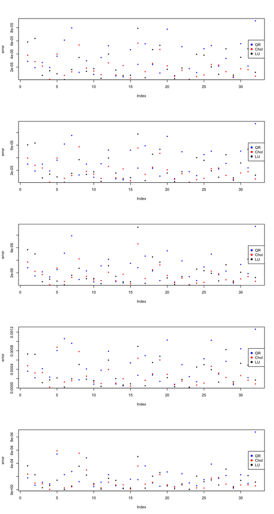

```r
# Utility functions for bookkeeping simulation results.
source(file.path("R", "num_linalg_sim_study_helper.R"))

n_sim <- 32L
mat_size <- 512L
cond_num <- 1e12
metrics <- c("norm", "median", "five_percentile", "ninety_five_percentile", "average")
  # TODO: add another metric and modify the helper script accordingly

rel_error_list <- lapply(
  c("lu", "chol", "qr"),
  function(method) pre_allocate_error_list(n_sim, metrics)
)

for (sim_index in 1:n_sim) {
  A <- rand_positive_def_matrix(mat_size, cond_num)
  x <- rnorm(mat_size)
  b <- matvec_ldouble(A, x)
  x_approx <- list(
    lu=solve(A, b),
    chol=solve_via_cholesky(A, b),
    qr=qr.solve(A, b, tol = .Machine$double.eps)
  )
  for (method in c("lu", "chol", "qr")) {
    rel_error <- lapply(
      metrics,
      function (metric) calc_rel_error(x, x_approx[[method]], metric)
    )
    names(rel_error) <- metrics
    for (metric in names(rel_error)) {
      rel_error_list[[method]][[metric]][sim_index] <- rel_error[[metric]]
    }
  }
}

# TODO: visually compare errors
par(mfrow=c(5,1))
plot(rel_error_list[["qr"]][["norm"]], col="blue", ylab="error", pch=19, cex=0.5)
points(rel_error_list[["chol"]][["norm"]], col="red", pch=19, cex=0.5)
points(rel_error_list[["lu"]][["norm"]], col="black", pch=19, cex=0.5)
legend("right", legend = c("QR", "Chol", "LU"), col = c("blue", "red", "black"), pch = c(19,19,19))

plot(rel_error_list[["qr"]][["median"]], col="blue", ylab="error", pch=19, cex=0.5)
points(rel_error_list[["chol"]][["median"]], col="red", pch=19, cex=0.5)
points(rel_error_list[["lu"]][["median"]], col="black", pch=19, cex=0.5)
legend("right", legend = c("QR", "Chol", "LU"), col = c("blue", "red", "black"), pch = c(19,19,19))

plot(rel_error_list[["qr"]][["five_percentile"]], col="blue", ylab="error", pch=19, cex=0.5)
points(rel_error_list[["chol"]][["five_percentile"]], col="red", pch=19, cex=0.5)
points(rel_error_list[["lu"]][["five_percentile"]], col="black", pch=19, cex=0.5)
legend("right", legend = c("QR", "Chol", "LU"), col = c("blue", "red", "black"), pch = c(19,19,19))

plot(rel_error_list[["qr"]][["ninety_five_percentile"]], col="blue", ylab="error", pch=19, cex=0.5)
points(rel_error_list[["chol"]][["ninety_five_percentile"]], col="red", pch=19, cex=0.5)
points(rel_error_list[["lu"]][["ninety_five_percentile"]], col="black", pch=19, cex=0.5)
legend("right", legend = c("QR", "Chol", "LU"), col = c("blue", "red", "black"), pch = c(19,19,19))

plot(rel_error_list[["qr"]][["average"]], col="blue", ylab="error", pch=19, cex=0.5)
points(rel_error_list[["chol"]][["average"]], col="red", pch=19, cex=0.5)
points(rel_error_list[["lu"]][["average"]], col="black", pch=19, cex=0.5)
legend("right", legend = c("QR", "Chol", "LU"), col = c("blue", "red", "black"), pch = c(19,19,19))
```